# factorMerger: a set of tools to support results from post-hoc testing

Agnieszka Sitko

2019-06-27

# Introduction

The aim of `factorMerger` is to provide a set of tools to support results from post hoc comparisons. Post hoc testing is an analysis performed after running *ANOVA* to examine differences between group means (of some response numeric variable) for each pair of groups (groups are defined by a factor variable).

This project arose from the need to create a method of post hoc testing which gives the hierarchical interpretation of relations between groups means. Thereby, for a given significance level we may divide groups into non-overlapping clusters.

# Algorithm inputs

In the current version the **factorMerger** package supports parametric models:

- one-dimensional Gaussian (with the argument `family = "gaussian"`),
- multi dimensional Gaussian (with the argument `family = "gaussian"`),
- binomial (with the argument `family = "binomial"`),
- survival (with the argument `family = "survival"`).

There are four algorithms available: adaptive, fast-adaptive, fixed and fast-fixed (they are set with the `method` argument of `mergeFactors`). *Fast* algorithms enable to unite only those groups whose group statistics (i.e. means in the Gaussian case) are close.

# Generating samples

To visualize functionalities of `factorMerger` we use samples or real data examples with response variable whose distribution follow one of the listed above. The corresponding factor variable is sampled uniformly from a finite set of a size $k$.

To do so, we may use function `generateSample` or `generateMultivariateSample`.

```r
library(factorMerger)
library(knitr)
library(dplyr)
randSample <- generateMultivariateSample(N = 100, k = 10, d = 3)
```

# Merging factors

`mergeFactors` is a function that performs hierarchical post hoc testing. As arguments it takes:

- matrix/data.frame/vector with numeric response,
- factor vector defining groups.

By default (with argument `abbreviate = TRUE`) factor levels are abbreviated and surrounded with brackets.

## Multi-dimensional Gaussian model

### Computations

```r
fmAll <- mergeFactors(response = randSample$response, factor = randSample$factor)
```

`mergeFactors` outputs with information about the ‘merging history’.

```r
mergingHistory(fmAll, showStats = TRUE) %>%
    kable()
```

|  | groupA | groupB | model | pvalVsFull | pvalVsPrevious |
| --- | --- | --- | --- | --- | --- |
| 0 |  |  | -411.9255 | 1.0000 | 1.0000 |
| 1 | (I) | (E) | -411.9382 | 0.9991 | 0.9991 |
| 2 | (A) | (J) | -412.0626 | 0.9997 | 0.9738 |
| 3 | (I)(E) | (A)(J) | -412.3915 | 0.9997 | 0.8975 |
| 4 | (D) | (B) | -412.9334 | 0.9996 | 0.8033 |
| 5 | (G) | (D)(B) | -414.2715 | 0.9966 | 0.4797 |
| 6 | (G)(D)(B) | (F) | -415.9719 | 0.9858 | 0.3647 |
| 7 | (H) | (I)(E)(A)(J) | -418.1367 | 0.9529 | 0.2518 |
| 8 | (G)(D)(B)(F) | (C) | -423.1086 | 0.6682 | 0.0234 |
| 9 | (H)(I)(E)(A)(J) | (G)(D)(B)(F)(C) | -430.4130 | 0.1582 | 0.0028 |

If we choose a *fast* version of merging one dimensional response is fitted using `isoMDS{MASS}`. Next, in each step only groups whose means are closed are compared.

```r
fm <- mergeFactors(response = randSample$response, factor = randSample$factor,
                   method = "fast-fixed")

mergingHistory(fm, showStats = TRUE) %>%
    kable()
```

|  | groupA | groupB | model | pvalVsFull | pvalVsPrevious |
| --- | --- | --- | --- | --- | --- |
| 0 |  |  | -411.9255 | 1.0000 | 1.0000 |
| 1 | (I) | (E) | -411.9382 | 0.9991 | 0.9991 |
| 2 | (I)(E) | (A) | -412.1038 | 0.9994 | 0.9607 |
| 3 | (I)(E)(A) | (J) | -412.3915 | 0.9997 | 0.9143 |
| 4 | (D) | (B) | -412.9334 | 0.9996 | 0.8033 |
| 5 | (I)(E)(A)(J) | (G) | -415.2840 | 0.9776 | 0.2262 |
| 6 | (I)(E)(A)(J)(G) | (D)(B) | -418.3399 | 0.8624 | 0.1264 |
| 7 | (I)(E)(A)(J)(G)(D)(B) | (F) | -421.3636 | 0.6959 | 0.1264 |
| 8 | (I)(E)(A)(J)(G)(D)(B)(F) | (C) | -426.9015 | 0.2673 | 0.0143 |
| 9 | (H) | (I)(E)(A)(J)(G)(D)(B)(F)(C) | -430.4130 | 0.1582 | 0.0794 |

### Final clusters

Algorithms implemented in the **factorMerger** package enable to create unequivocal partition of a factor. Below we present how to extract the partition from the `mergeFactor` output.

- predict new labels for observations

```r
cutTree(fm)
```

```
#>   [1] (C)          (G)          (F)          (I)(E)(A)(J) (G)
#>   [6] (I)(E)(A)(J) (I)(E)(A)(J) (D)(B)       (G)          (F)
#>  [11] (D)(B)       (G)          (I)(E)(A)(J) (I)(E)(A)(J) (I)(E)(A)(J)
#>  [16] (D)(B)       (I)(E)(A)(J) (D)(B)       (D)(B)       (C)
#>  [21] (H)          (D)(B)       (D)(B)       (D)(B)       (D)(B)
#>  [26] (F)          (H)          (F)          (I)(E)(A)(J) (G)
#>  [31] (H)          (I)(E)(A)(J) (D)(B)       (I)(E)(A)(J) (G)
#>  [36] (I)(E)(A)(J) (H)          (H)          (D)(B)       (I)(E)(A)(J)
#>  [41] (I)(E)(A)(J) (I)(E)(A)(J) (I)(E)(A)(J) (I)(E)(A)(J) (C)
#>  [46] (D)(B)       (G)          (H)          (I)(E)(A)(J) (C)
#>  [51] (I)(E)(A)(J) (I)(E)(A)(J) (I)(E)(A)(J) (D)(B)       (I)(E)(A)(J)
#>  [56] (I)(E)(A)(J) (G)          (I)(E)(A)(J) (F)          (D)(B)
#>  [61] (I)(E)(A)(J) (F)          (D)(B)       (C)          (H)
#>  [66] (C)          (H)          (G)          (I)(E)(A)(J) (G)
#>  [71] (C)          (H)          (D)(B)       (F)          (I)(E)(A)(J)
#>  [76] (I)(E)(A)(J) (F)          (I)(E)(A)(J) (D)(B)       (G)
#>  [81] (D)(B)       (I)(E)(A)(J) (I)(E)(A)(J) (D)(B)       (I)(E)(A)(J)
#>  [86] (D)(B)       (G)          (G)          (H)          (I)(E)(A)(J)
#>  [91] (D)(B)       (I)(E)(A)(J) (H)          (F)          (I)(E)(A)(J)
#>  [96] (G)          (C)          (I)(E)(A)(J) (D)(B)       (H)
#> Levels: (H) (I)(E)(A)(J) (G) (D)(B) (F) (C)
```

By default, `cutTree` returns a factor split for the optimal GIC (with penalty = 2) model. However, we can specify different metrics (`stat = c("loglikelihood", "p-value", "GIC"`) we would like to use in cutting. If `loglikelihood` or `p-value` is chosen an exact threshold must be given as a `value` parameter. Then `cutTree` returns factor for the smallest model whose statistic is higher than the threshold. If we choose `GIC` then `value` is interpreted as GIC penalty.

```r
mH <- mergingHistory(fm, T)
thres <- mH$model[nrow(mH) / 2]
cutTree(fm, stat = "loglikelihood", value = thres)
```

```
#>   [1] (C)          (G)          (F)          (I)(E)(A)(J) (G)
#>   [6] (I)(E)(A)(J) (I)(E)(A)(J) (D)(B)       (G)          (F)
#>  [11] (D)(B)       (G)          (I)(E)(A)(J) (I)(E)(A)(J) (I)(E)(A)(J)
#>  [16] (D)(B)       (I)(E)(A)(J) (D)(B)       (D)(B)       (C)
#>  [21] (H)          (D)(B)       (D)(B)       (D)(B)       (D)(B)
#>  [26] (F)          (H)          (F)          (I)(E)(A)(J) (G)
#>  [31] (H)          (I)(E)(A)(J) (D)(B)       (I)(E)(A)(J) (G)
#>  [36] (I)(E)(A)(J) (H)          (H)          (D)(B)       (I)(E)(A)(J)
#>  [41] (I)(E)(A)(J) (I)(E)(A)(J) (I)(E)(A)(J) (I)(E)(A)(J) (C)
#>  [46] (D)(B)       (G)          (H)          (I)(E)(A)(J) (C)
#>  [51] (I)(E)(A)(J) (I)(E)(A)(J) (I)(E)(A)(J) (D)(B)       (I)(E)(A)(J)
#>  [56] (I)(E)(A)(J) (G)          (I)(E)(A)(J) (F)          (D)(B)
#>  [61] (I)(E)(A)(J) (F)          (D)(B)       (C)          (H)
#>  [66] (C)          (H)          (G)          (I)(E)(A)(J) (G)
#>  [71] (C)          (H)          (D)(B)       (F)          (I)(E)(A)(J)
#>  [76] (I)(E)(A)(J) (F)          (I)(E)(A)(J) (D)(B)       (G)
#>  [81] (D)(B)       (I)(E)(A)(J) (I)(E)(A)(J) (D)(B)       (I)(E)(A)(J)
#>  [86] (D)(B)       (G)          (G)          (H)          (I)(E)(A)(J)
#>  [91] (D)(B)       (I)(E)(A)(J) (H)          (F)          (I)(E)(A)(J)
#>  [96] (G)          (C)          (I)(E)(A)(J) (D)(B)       (H)
#> Levels: (H) (I)(E)(A)(J) (G) (D)(B) (F) (C)
```

In this example data partition is created for the last model from the merging path whose loglikelihood is greater than -412.9334.

- get final clusters and clusters dictionary

```r
getOptimalPartition(fm)
```

```
#> [1] "(H)"          "(I)(E)(A)(J)" "(G)"          "(D)(B)"
#> [5] "(F)"          "(C)"
```

Function `getOptimalPartition` returns a vector with the final cluster names from the factorMerger object.

```r
getOptimalPartitionDf(fm)
```

```
#>    orig         pred
#> 1   (C)          (C)
#> 2   (G)          (G)
#> 3   (F)          (F)
#> 4   (E) (I)(E)(A)(J)
#> 6   (A) (I)(E)(A)(J)
#> 8   (D)       (D)(B)
#> 11  (B)       (D)(B)
#> 15  (J) (I)(E)(A)(J)
#> 21  (H)          (H)
#> 41  (I) (I)(E)(A)(J)
```

Function `getOptimalPartitionDf` returns a dictionary in a data frame format. Each row gives an original label of a factor level and its new (cluster) label.

Similarly to `cutTree`, functions `getOptimalPartition` and `getOptimalPartitionDf` take arguments `stat` and `threshold`.

### Visualizations

We may plot results using function `plot`.

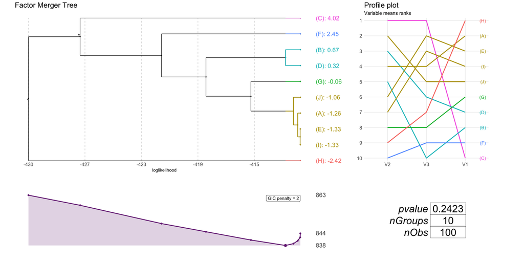

```r
plot(fm, panel = "all", nodesSpacing = "equidistant", colorCluster = TRUE)
```

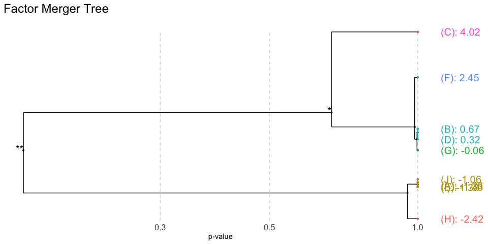

```r
plot(fmAll, panel = "tree", statistic = "p-value",
     nodesSpacing = "effects", colorCluster = TRUE)
```

[figure not shown]

```r
plot(fm, colorCluster = TRUE, panel = "response")
```

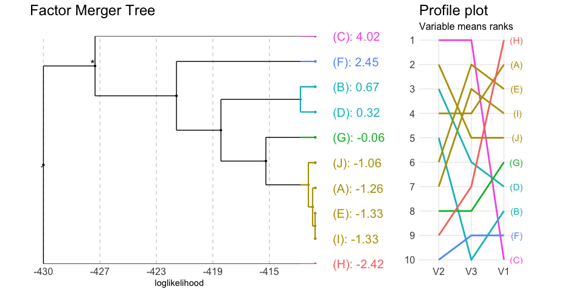

```r
plot(fm, colorCluster = TRUE, panel = "response", responsePanel = "profile")
```

In the above plots colours are connected with the group. The plot on the right shows means rankings for all variables included in the algorithm.

It is also possible to plot *GIC* together with the merging path plot.

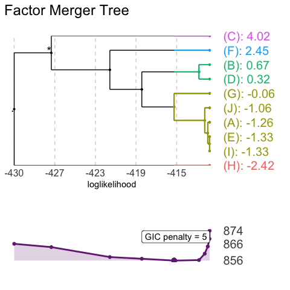

```r
plot(fm, panel = "GIC", penalty = 5)
```

Model with the lowest GIC is marked.

## One-dimensional Gaussian model

```r
oneDimRandSample <- generateSample(1000, 10)
```

```r
oneDimFm <- mergeFactors(response = oneDimRandSample$response, factor = oneDimRandSample$factor,
                         method = "fixed")
mergingHistory(oneDimFm, showStats = TRUE) %>%
    kable()
```

|  | groupA | groupB | model | pvalVsFull | pvalVsPrevious |
| --- | --- | --- | --- | --- | --- |
| 0 |  |  | -1395.130 | 1.0000 | 1.0000 |
| 1 | (C) | (H) | -1395.130 | 0.9874 | 0.9874 |
| 2 | (D) | (B) | -1395.131 | 0.9994 | 0.9752 |
| 3 | (A) | (J) | -1395.133 | 0.9999 | 0.9442 |
| 4 | (C)(H) | (F) | -1395.138 | 1.0000 | 0.9256 |
| 5 | (C)(H)(F) | (G) | -1395.169 | 0.9999 | 0.8025 |
| 6 | (D)(B) | (C)(H)(F)(G) | -1395.311 | 0.9992 | 0.5949 |
| 7 | (A)(J) | (I) | -1395.799 | 0.9877 | 0.3243 |
| 8 | (E) | (D)(B)(C)(H)(F)(G) | -1396.616 | 0.9374 | 0.2021 |
| 9 | (E)(D)(B)(C)(H)(F)(G) | (A)(J)(I) | -1400.097 | 0.3612 | 0.0084 |

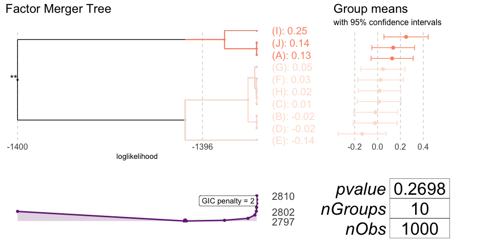

```r
plot(oneDimFm, palette = "Reds")
```

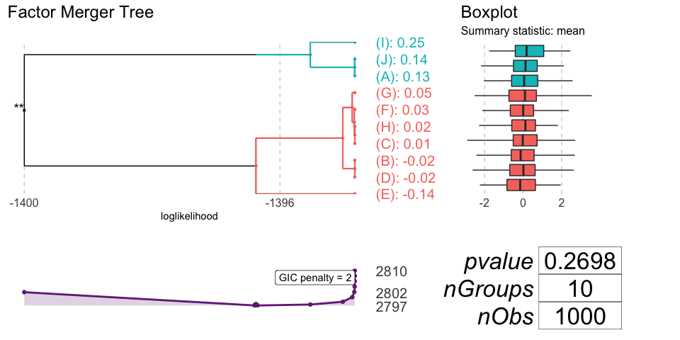

```r
plot(oneDimFm, responsePanel = "boxplot", colorCluster = TRUE)
```

## Binomial model

If `family = "binomial"` response must have to values: `0` and `1` (`1` is interpreted as success).

```r
binomRandSample <- generateSample(1000, 10, distr = "binomial")
table(binomRandSample$response, binomRandSample$factor) %>%
    kable()
```

|  | J | H | G | A | D | F | C | B | I | E |
| --- | --- | --- | --- | --- | --- | --- | --- | --- | --- | --- |
| 0 | 88 | 56 | 46 | 54 | 51 | 29 | 24 | 20 | 8 | 3 |
| 1 | 16 | 28 | 27 | 64 | 67 | 63 | 79 | 84 | 93 | 100 |

```r
binomFm <- mergeFactors(response = binomRandSample$response,
                        factor = binomRandSample$factor,
                        family = "binomial",
                        method = "fast-adaptive")
mergingHistory(binomFm, showStats = TRUE) %>%
    kable()
```

|  | groupA | groupB | model | pvalVsFull | pvalVsPrevious |
| --- | --- | --- | --- | --- | --- |
| 0 |  |  | -513.9760 | 1.0000 | 1.0000 |
| 1 | (A) | (D) | -514.0533 | 0.6943 | 0.6943 |
| 2 | (H) | (G) | -514.1677 | 0.8256 | 0.6324 |
| 3 | (C) | (B) | -514.4240 | 0.8264 | 0.4740 |
| 4 | (I) | (E) | -515.7203 | 0.4796 | 0.1074 |
| 5 | (F) | (C)(B) | -517.4859 | 0.2192 | 0.0602 |
| 6 | (J) | (H)(G) | -523.9112 | 0.0029 | 0.0003 |
| 7 | (A)(D) | (F)(C)(B) | -535.8790 | 0.0000 | 0.0000 |
| 8 | (A)(D)(F)(C)(B) | (I)(E) | -572.9249 | 0.0000 | 0.0000 |
| 9 | (J)(H)(G) | (A)(D)(F)(C)(B)(I)(E) | -663.5725 | 0.0000 | 0.0000 |

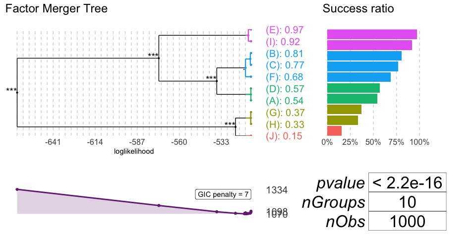

```r
plot(binomFm, colorCluster = TRUE, penalty = 7)
```

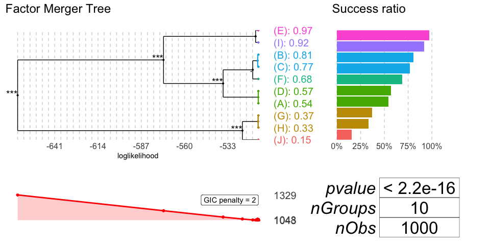

```r
plot(binomFm, gicPanelColor = "red")
```

## Survival model

If `family = "survival"` response must be of a class `Surv`.

```r
 library(survival)
 data(veteran)
 survResponse <- Surv(time = veteran$time,
                  event = veteran$status)
 survivalFm <- mergeFactors(response = survResponse,
                    factor = veteran$celltype,
                    family = "survival")
```

```r
 mergingHistory(survivalFm, showStats = TRUE) %>%
     kable()
```

|  | groupA | groupB | model | pvalVsFull | pvalVsPrevious |
| --- | --- | --- | --- | --- | --- |
| 0 |  |  | -493.0247 | 1.0000 | 1.0000 |
| 1 | (smll) | (aden) | -493.1951 | 0.5594 | 0.5594 |
| 2 | (sqms) | (larg) | -493.5304 | 0.6031 | 0.4128 |
| 3 | (sqms)(larg) | (smll)(aden) | -505.4491 | 0.0000 | 0.0000 |

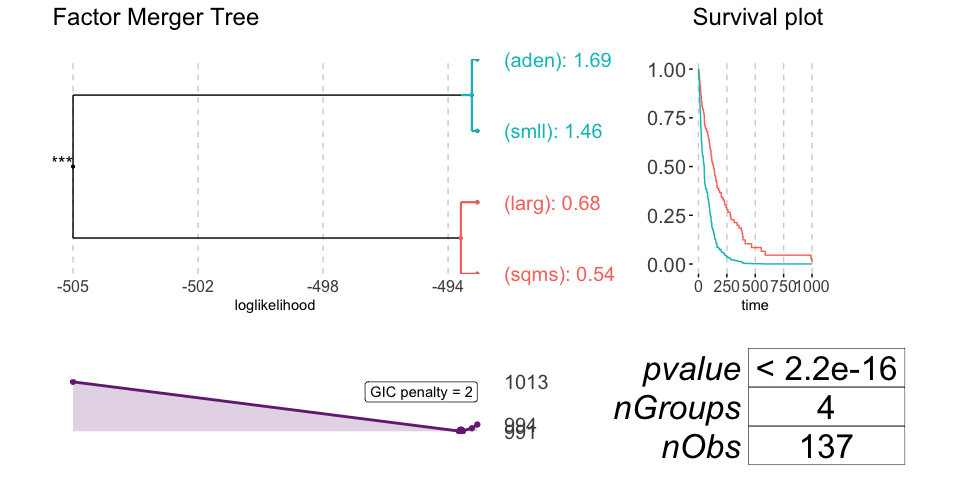

```r
 plot(survivalFm)
```

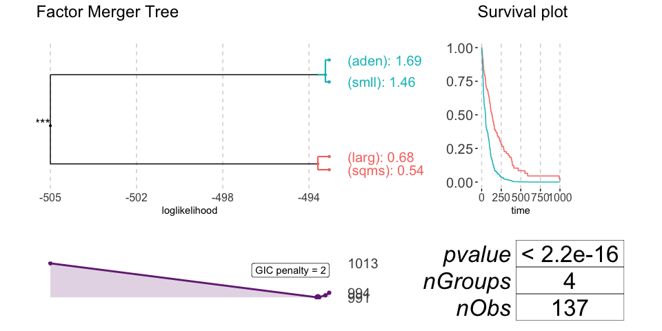

```r
 plot(survivalFm, nodesSpacing = "effects", colorCluster = TRUE)
```